# Hw3_Random_variables

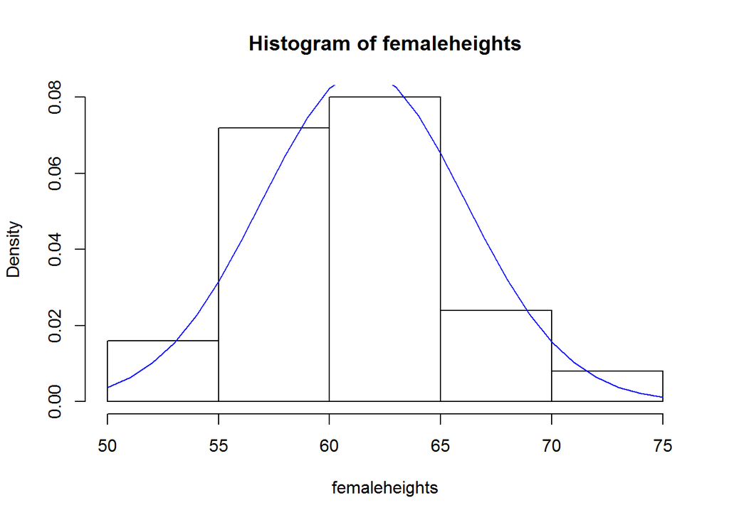

```r
hist(femaleheights,probability = TRUE )
lines(50:75,dnorm(50:75,mean(femaleheights),sd(femaleheights)), col="blue")
```

```r
#Above charts shows that the heights are normally distributed. It matches with the randomly generated normal distribution charts.
```

[output not shown]

3.22 Defective rate. A machine that produces a special type of transistor (a component of computers) has a 2% defective rate. The production is considered a random process where each transistor is independent of the others.

1. What is the probability that the 10th transistor produced is the first with a defect?

```r
(1 - .02)^9*.02
```

```
## [1] 0.01667496
```

2. What is the probability that the machine produces no defective transistors in a batch of 100?

```r
(1 - .02)^100
```

```
## [1] 0.1326196
```

3. On average, how many transistors would you expect to be produced before the first with a defect? What is the standard deviation?

```r
#mean. We would expect around 50 transistors
1/0.02
```

```
## [1] 50
```

```r
#sd
sqrt((1-0.02)/0.02^2)
```

```
## [1] 49.49747
```

4. Another machine that also produces transistors has a 5% defective rate where each transistor is produced independent of the others. On average how many transistors would you expect to be produced with this machine before the first with a defect? What is the standard deviation?

```r
#mean. We would expect around 20 transistors
1/0.05
```

```
## [1] 20
```

```r
#sd
sqrt((1-0.05)/0.05^2)
```

```
## [1] 19.49359
```

5. Based on your answers to parts (c) and (d), how does increasing the probability of an event affect the mean and standard deviation of the wait time until success?

Increasing the probability of success, will inversely affect the mean and mean. So if the probability is 50%, then the mean and SD will be less. So we might expect failure very frequently.

3.38 Male children. While it is often assumed that the probabilities of having a boy or a girl are the same, the actual probability of having a boy is slightly higher at 0.51. Suppose a couple plans to have 3 kids.

1. Use the binomial model to calculate the probability that two of them will be boys.

```r
n=3
k=2
p=.51

#probability that two of them will be boys are

dbinom(k,n,p)
```

```
## [1] 0.382347
```

2. Write out all possible orderings of 3 children, 2 of whom are boys. Use these scenarios to calculate the same probability from part (a) but using the addition rule for disjoint outcomes. Confirm that your answers from parts (a) and (b) match.

```r
# All possible outcomes

permn(c("boy","boy","girl"))
```

```
## [[1]]
## [1] "boy"  "boy"  "girl"
##
## [[2]]
## [1] "boy"  "girl" "boy"
##
## [[3]]
## [1] "girl" "boy"  "boy"
##
## [[4]]
## [1] "girl" "boy"  "boy"
##
## [[5]]
## [1] "boy"  "girl" "boy"
##
## [[6]]
## [1] "boy"  "boy"  "girl"
```

```r
#As we are counting for six times, we need to multiply by 6. Then we have counted two times. So we need to divide by 2. Or unique outcomes
(p*p*(1-p))*(6/2)
```

```
## [1] 0.382347
```

3. If we wanted to calculate the probability that a couple who plans to have 8 kids will have 3 boys, briefly describe why the approach from part (b) would be more tedious than the approach from part (a).

```r
#Actual probability of getting 3 boys out of 8 kids is 20.98
dbinom(3,8,.51)
```

```
## [1] 0.2098355
```

```r
#By regular method

(p*p*p*(1-p)*(1-p)*(1-p)*(1-p)*(1-p))*length(combn(c("boy","boy","boy","girl","girl","girl","girl","girl"),3))
```

```
## [1] 0.6295065
```

```r
# It is more tedious to do manually. Because we need to calculate the combinations and then multiply with the probability of each event
```

3.42 Serving in volleyball. A not-so-skilled volleyball player has a 15% chance of making the serve, which involves hitting the ball so it passes over the net on a trajectory such that it will land in the opposing team’s court. Suppose that her serves are independent of each other.

1. What is the probability that on the 10th try she will make her 3rd successful serve?

```r
#Probability of 3rd successful serve in
dbinom(2,9,.15)
```

```
## [1] 0.2596674
```

```r
n <- 10    #number of attempts
k <- 3     #successful serves
p <- 0.15  #successful serve prob


factorial(n - 1) / (factorial(k-1) * (factorial(n - k))) * p^k * (1-p)^(n-k)
```

```
## [1] 0.03895012
```

2. Suppose she has made two successful serves in nine attempts. What is the probability that her 10th serve will be successful?

As these serves are independent of each other, the probability of any one individual serve is 15%.

3. Even though parts (a) and (b) discuss the same scenario, the probabilities you calculated should be different. Can you explain the reason for this discrepancy?

Probability of single event is different than the probability of combinations. (a) is about future serves. (b) is about single successful event.